# Assignment 2: Heterogeneity Test

# Interaction Plots

## Differentiating Mean Responses

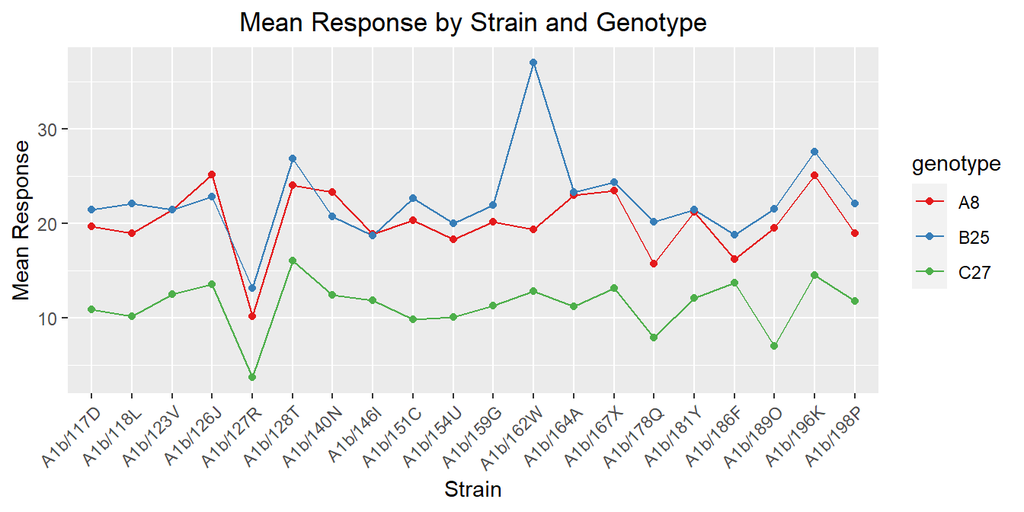

The first meaningful difference in response you can see is that of B25’s reaction to A1b/162W, y the mean response it is evident that there is a strong interaction between said genotype and strain. Another interesting interaction is between that of genotype C27 and strain A1b/189O. Genotype’s A8 and B25’s response to strain A1b/189O is somewhere between that of A1b/189F and A1b/196K, almost equivalent A1b/198P. However genotype C27 has a much weaker response in comparison showing a negative interaction with regards to mean response. We can also see that C27 has on average around half the mean response of both A8 and B25 which are more homogeneous. Differentiating between A8 and B25 (outside of what has already been stated) requires a look at their distributions which we will do with the next figure.

## Differentiating Mean Response Distributions

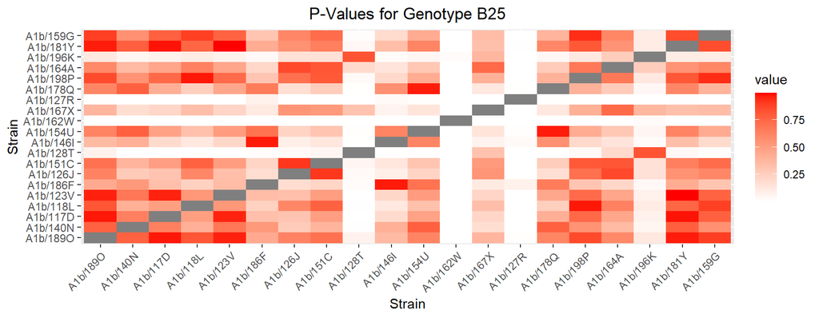

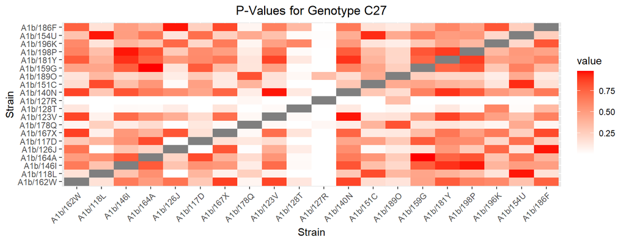

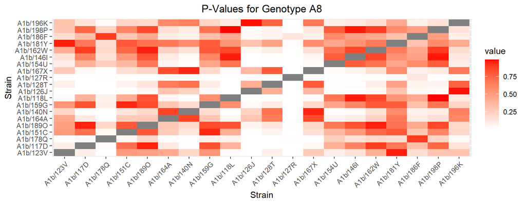

Strain A1b/127R has a p<0.05 in relation to each strain’s mean response, in addition, for B25 both strains A1b/162W and A1b/128T have p<0.05. Thus indicating a global genotypic effect for strain A1b/127R and local genotypic effects for A1b/162W and A1b/128T.

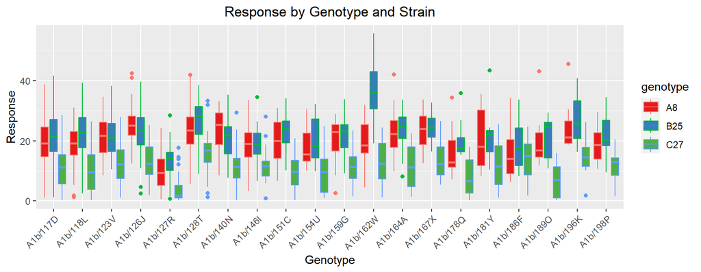

If we take the distributions that the previous p-value heatmaps were generated with, we can get a better understanding of the mean response of each genotype to a given strain. For example if we look at A1b/127R, of which we found to have a global genotypic effect, we can see that the three genotypes are have lower mean responses and distributions.

For B25, starting with A1b/162W we can see that its mean response is near twice the average for interstrain comparisons. Then for B25 A1b/128T we can see that the Interquartile range is generally shifted higher by ~5.

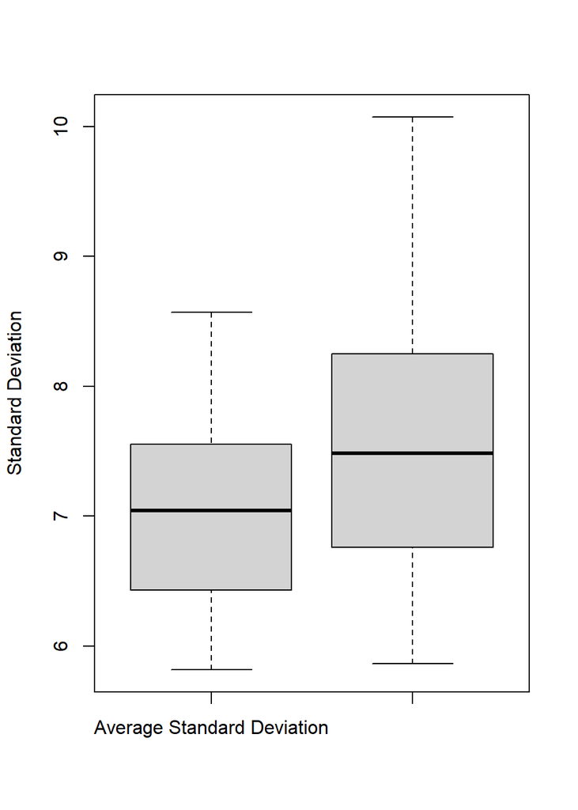

```
##                 Df Sum Sq Mean Sq F value Pr(>F)
## avg_sd_shuffled  1  0.055  0.0552   0.076  0.786
## Residuals       18 13.068  0.7260
```

The ANOVA test performed on the same data compares the average standard deviation of the response variable between the shuffled and non-shuffled strains for each genotype. The ANOVA test determines whether there is a significant difference in the average standard deviation between the shuffled and non-shuffled strains.